# peer asssessment 1

```r
library(zoo)
setwd("C:/datasciencehw/reproducible research")
data<-read.csv(file="activity.csv",header=TRUE, sep=",")
```

```r
date<-unique(data$date)
TOTAL<-rep(0,length(date))
MEAN<-rep(0,length(date))
MEDIAN<-rep(0,length(date))
for (i in 1:length(date)){
  MEAN[i]<-mean(data[data$date==date[i],"steps"],na.rm=TRUE)
    MEDIAN[i]<-median(data[data$date==date[i],"steps"],na.rm=TRUE)
    TOTAL[i]<-sum(data[data$date==date[i],"steps"],na.rm=TRUE)
}
```

Make a histogram of the total number of steps taken each day

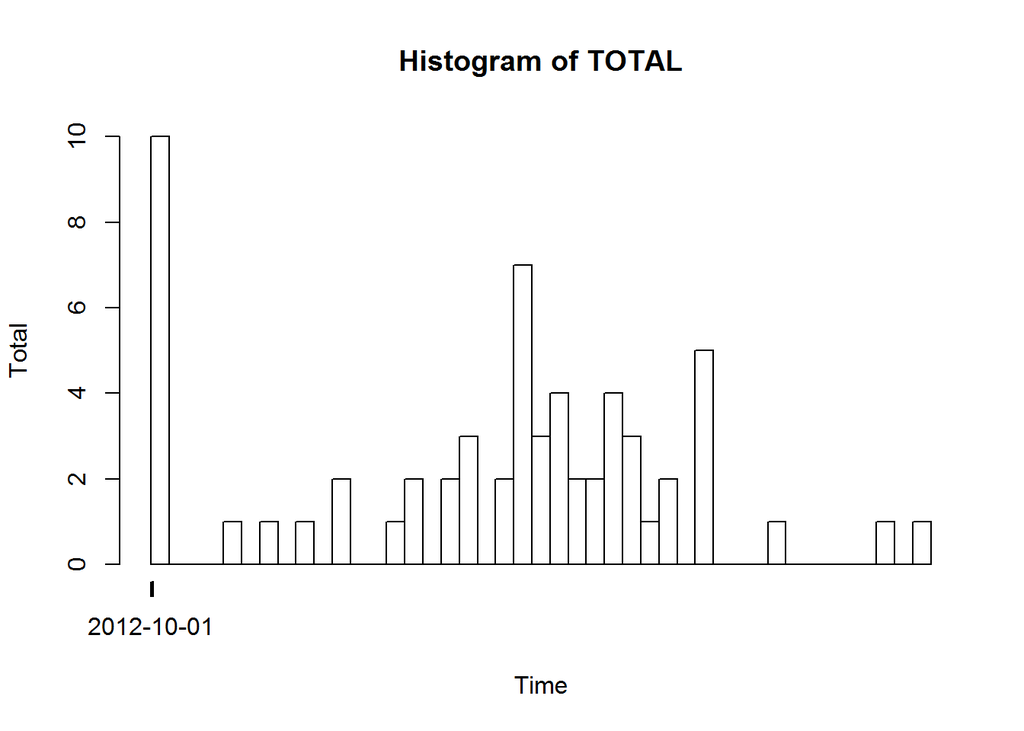

```r
hist(TOTAL,xlab = "Time", ylab="Total", length(TOTAL),axes = FALSE)
axis(1, at=seq(1,length(TOTAL),by=1),labels=as.character(date))
axis(2)
```

```r
MEDIAN<-cbind(MEDIAN,as.character(date))
MEAN<-cbind(MEAN,as.character(date))
write.table(x=MEDIAN,file="median.csv",append=FALSE,sep=",",row.names=FALSE,col.names=FALSE)
write.table(x=MEAN,file="mean.csv",append=FALSE,sep=",",row.names=FALSE,col.names=FALSE)
```

Make a time series plot (i.e. type = “l”) of the 5-minute interval (x-axis) and the average number of steps taken, averaged across all days (y-axis)

```r
matrix.temp<-matrix(data[,1],ncol=length(date),byrow=FALSE)
matrix.mean<-rowMeans(matrix.temp,na.rm=TRUE)
```

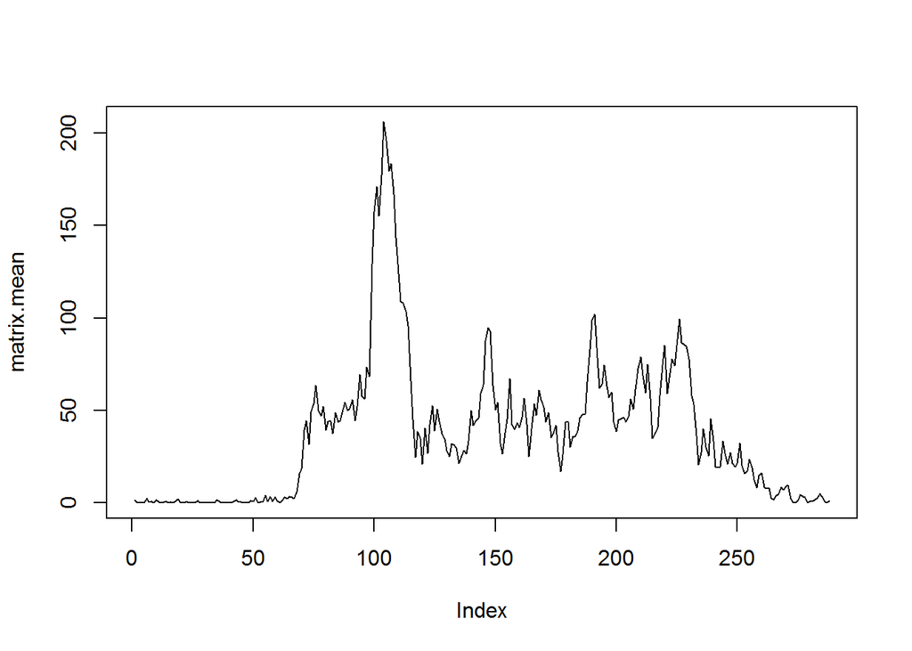

Which 5-minute interval, on average across all the days in the dataset, contains the maximum number of steps

```r
which(matrix.mean==max(matrix.mean,na.rm=TRUE))
```

```
## [1] 104
```

Calculate and report the total number of missing values in the dataset (i.e. the total number of rows with NAs)

```r
Index<-which(is.na(data$steps))
length(Index)
```

```
## [1] 2304
```

Create a new dataset that is equal to the original dataset but with the missing data filled in.

```r
for (i in 1:dim(matrix.temp)[1]){
  index.temp<-which(is.na(matrix.temp[i,]))
    if (length(index.temp)>0){
    matrix.temp[i,index.temp]<-matrix.mean[i]
}}
vector.temp<-as.vector(matrix.temp)
data.new<-data
data.new[,1]<-vector.temp
```

```r
TOTAL.new<-rep(0,length(date))
MEAN.new<-rep(0,length(date))
MEDIAN.new<-rep(0,length(date))
for (i in 1:length(date)){
  MEAN.new[i]<-mean(data.new[data.new$date==date[i],"steps"],na.rm=TRUE)
    MEDIAN.new[i]<-median(data.new[data.new$date==date[i],"steps"],na.rm=TRUE)
    TOTAL.new[i]<-sum(data.new[data.new$date==date[i],"steps"],na.rm=TRUE)
}
```

Make a histogram of the total number of steps taken each day

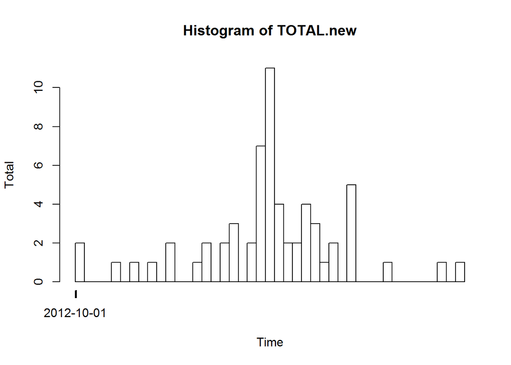

```r
hist(TOTAL.new,xlab = "Time", ylab="Total", length(TOTAL.new),axes = FALSE)
axis(1, at=seq(1,length(TOTAL.new),by=1),labels=as.character(date))
axis(2)
```

```r
MEDIAN.new<-cbind(MEDIAN.new,as.character(date))
MEAN.new<-cbind(MEAN.new,as.character(date))
write.table(x=MEDIAN.new,file="median_new.csv",append=FALSE,sep=",",row.names=FALSE,col.names=FALSE)
write.table(x=MEAN.new,file="mean_new.csv",append=FALSE,sep=",",row.names=FALSE,col.names=FALSE)
```

Create a new factor variable in the dataset with two levels indicating whether a given date is a weekday or weekend day.

```r
date<-as.Date(data$date)
weekdays<-weekdays(date)
index.temp<-(weekdays!="Saturday")&(weekdays!="Sunday")
index.temp[index.temp==TRUE]="weekday"
index.temp[index.temp==FALSE]="weekend"
data$weekdays.true<-index.temp
```

Make a time series plot (i.e. type = “l”) of the 5-minute interval (x-axis) and the average number of steps taken, averaged across all days (y-axis) for weekdays

```r
date<-unique(date)
matrix.temp<-matrix(data[data$weekdays.true=="weekday",1],nrow=dim(data)[1]/length(date),byrow=FALSE)
matrix.mean<-rowMeans(matrix.temp,na.rm=TRUE)
```

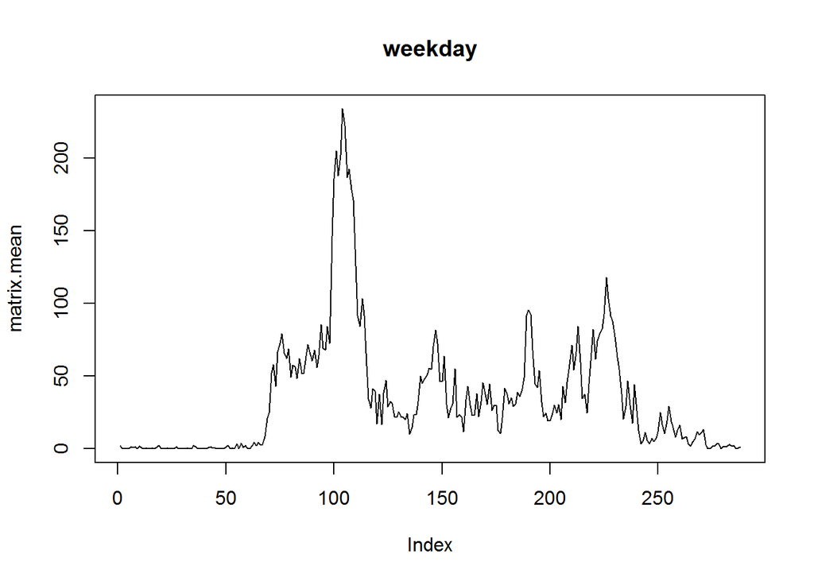

Make a time series plot (i.e. type = “l”) of the 5-minute interval (x-axis) and the average number of steps taken, averaged across all days (y-axis) for weekends

```r
date<-unique(date)
matrix.temp<-matrix(data[data$weekdays.true=="weekend",1],nrow=dim(data)[1]/length(date),byrow=FALSE)
matrix.mean<-rowMeans(matrix.temp,na.rm=TRUE)
```

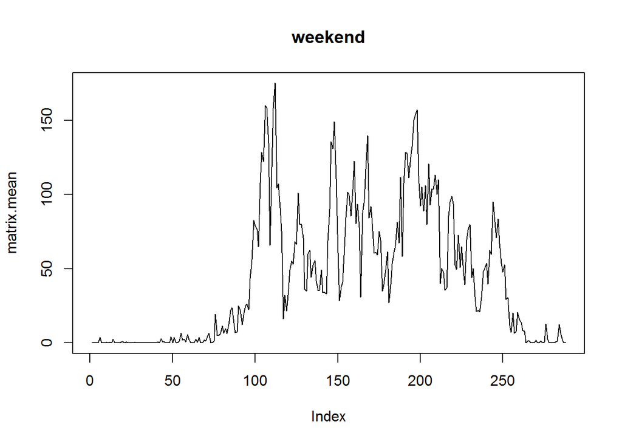